# EXPLORATORY DATA ANALYSIS FOR DIFFERENT USAGE OF MOBILE HEALTH APPLICATION

### Rating based on the purpose of the use of the application by Sex

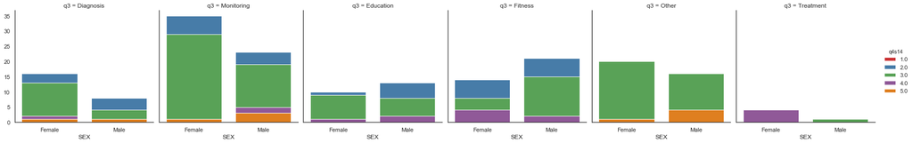

```python
fig =sns.FacetGrid(data=df,col='q3',hue='q4s14',palette='Set1',size=4,aspect=1).map(sns.countplot,'SEX',order=df.SEX.unique()).add_legend()
```

#### The analysis shows that the application is best good for Diagnosis, Education, Fitness and Monitoring.

### Rating based on performance,Engagement, and Ease of use

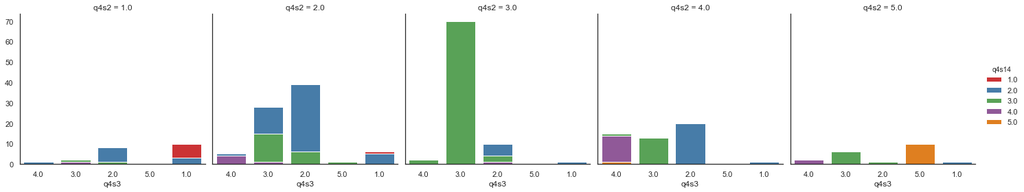

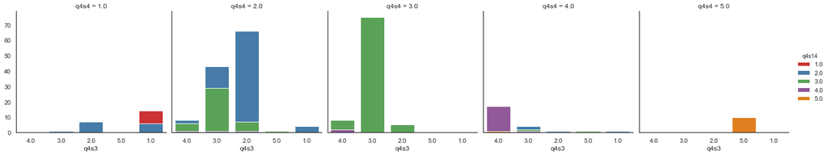

```python
fig =sns.FacetGrid(data=df,col='q4s2',hue='q4s14',palette='Set1',size=4,aspect=1).map(sns.countplot,'q4s3',order=df.q4s3.unique()).add_legend()
fig =sns.FacetGrid(data=df,col='q4s4',hue='q4s14',palette='Set1',size=4,aspect=1).map(sns.countplot,'q4s3',order=df.q4s3.unique()).add_legend()
```

#### The analysis shows that the participants are satisfield with the performance of the application, interactivity and ease of use.

## SUMMARY

### 34 participants strongly agreed that the application is easy to use, 179 partcipants agreed, 104 have not decided, 38 disagree and 13 strongly disagree.

### 28 participants strongly agreed that the application is of good performance,103 participants agreed, 167 have not decided, 55 disagree and 15 strong disagree.

### The analysis shows that 31 participants strongly agreed that the application is entertaining, 122 participants agreed, 108 have not decided, 76 disagree and 31 strongly disagree. The number of participants that agreed is much more, we can conclude that the application is entertaining.

### Overall Rating: 32 participants strongly agreed that the overall rating of the application is good, 158 participants agreed, 143 participants have not decided , 24 participants disagreed and 11 participants strongly disagreed.